# October 25 Update: computing equilibria of modified Keen model

Emma Holmes

## Differential System

The Keen model with prices and dividends can be written as the following system of three differential equations:

$$\begin{align}
\dot{\lambda} &= \lambda \left[ g(\pi) - \alpha - \beta \right]
\label{eq:lambda}\\
\dot{\omega} &= \omega \left[ \Phi(\lambda) - \alpha - i(\omega) \right]
\label{eq:omega}\\
\dot{d} &= \kappa(\pi) + \pi [\Delta(\pi) -1] - \delta \nu - d \left[ i(\omega) + g(\pi) \right]
\label{eq:debt}
\end{align}$$

where the following are left as auxiliary equations for ease of reading:
$$\begin{align}
\pi &= \pi(\omega,d) = 1 - \omega - r d - \delta \nu \\
i(\omega) &= \eta \, (\mu \omega - 1) \\
g(\pi) &=\frac{\kappa(\pi)}{\nu} - \delta
\end{align}$$

Note that I have assumed that $\beta(N) = \beta$, i.e. that the workforce $N$ grows exponentially.

These are nearly the same equations as given in Grasselli and Nguyen Huu (2015), with the addition of dividends.

## Code for the model

The following code sets up the run:

```r
# Scenarios
# Allows comparison between different investment and dividend scenarios, which are:
# A: low dividends, investment a function of retained profit share (realistic scenario)
# B: high dividends, investment a function of profit share ("Coping" AFD scenario)
# C: high dividends, investment a function of retained profit share
# D: low dividends, investment a function of profit share

#==============================================================================
# Packages
library("deSolve")
library("RColorBrewer")

# Colour palettes for graphs
greens <- brewer.pal(n = 6, name = "Greens")
colourful <- brewer.pal(n = 3, name = "Set1")
colour2 <- brewer.pal(n = 3, name = "Set2")

source('1c_pars_nc.R')  # load parameters

### Set initial conditions
# These initial conditions are from Bovari et al. (2018) "Coping with Collapse"
# and are estimated for the case where the one country is the entire world

IC <- c(
  lambda  =  0.95,     # employment rate of the global economy
  omega   =  0.5782,   # wage share of the economy
  debt    =  1.5328   # private debt ratio of the economy
)

#=================================================================================
# Set up simulation
Time <- c(
  start         =     2019,
  end           =     2300,
  step          =     0.05
)

Active <- list(
  Phillips     =   'asymptotic', # linear / asymptotic
  Invest       =   'arctan',     # linear / arctan
  Scenario     =   'B'          # A / B / C / D

)
```

The following code solves the model using DEsolve. Note that the use of the `with` function has made the code more readable.

```r
### Simulation file
simulation <- function(time, init_state, parms, active, method = 'lsoda',
                       show_end_results = TRUE, show_graph = TRUE,
                       montecarlo = F) {

  start_time <- proc.time()

  #===========================================================================
  # time sequence for ode
  time_seq <- seq(0, time[['end']] - time[['start']], by = time[['step']])
  init_vars <- c(init_state,
                 counter =0)

  #============================================================================
  ## DIFFERENTIAL SYSTEM
  # Function for deSolve:
  Keen_w_prices <- function(t, state, parms) {
    with(as.list(c(parms,state)), {
      ### Auxiliary equations
      # Profit share
      pi <- 1 - omega - r * debt - delta * nu
      # inflation
      i  <- eta * (mu * (omega + omitted) - 1)
      # investment function
      kappa <- f_inv(pi = pi, pars = parms, active = active)
      # growth rate of the economy
      g  <-  kappa / nu - delta
      # Phillips curve function
      phill <- f_phill(lambda = lambda, pars = parms, active = active)
      # dividends function
      div <- f_div(pi = pi, pars = parms, active = active)

      ### Differential system
      # employment rate
      d_lambda <- lambda * (g - alpha - beta)
      # wage share
      d_omega  <- omega * (phill - alpha - i)
      # debt share
      d_debt <- kappa + pi * (div - 1) - delta * nu - debt * (i + g)

      # Counter
      d_counter <- 1

      # ===========================================================================
      ## Return the list of gradients
      return(list(c(
        d_lambda   =  d_lambda ,
        d_omega    =  d_omega,
        d_debt     =  d_debt,
        d_counter  =  d_counter)))
    })
  }

  #==============================================================================
  ## SIMULATION
  simulation <- as.data.frame(ode(func = Keen_w_prices,
                                  method = method,
                                  y = init_vars,
                                  parms = c(parms,time),
                                  times = time_seq))

  # ============================================================================
  # REMAINING VARIABLES COMPUTATION

  compute.remaining <- function(sim = simulation, params = c(parms,time)){
    with(as.list(c(sim,params)), {

      pi <- 1 - omega - r * debt  - delta * nu   # profit share
      i  <- eta * (mu * (omega + omitted) - 1)    # inflation

      sim_output <- data.frame(
        year     = start + time,
        counter  = counter,
        lambda   = lambda,
        omega    = omega,
        debt     = debt,
        pi       = pi,
        i        = i)

      return(sim_output)
    })
  }

  # ============================================================================
  # Return data frame
  simulation_output <- compute.remaining()
  return(simulation_output)
}

# List function
listfunc <- c('simulation')
source('funcs.R')  # load functions
```

Finally, I run an example of scenario B, where dividends are high and investment is a function of profit share (the “Coping” model of Bovari et al. (2018)).

```r
#================================================================================
## Run a scenario
Sim <- simulation(time             = Time,
                   init_state       = IC,
                   parms            = Pars,
                   active           = Active,
                   method           = 'lsoda', # integration scheme: lsoda / rk4
                   show_end_results = FALSE,  # T/F: print out ending values of variables
                   show_graph       = TRUE   # T/F: print out graphs of some key variables
)
```

Here are plots of the computed variables:

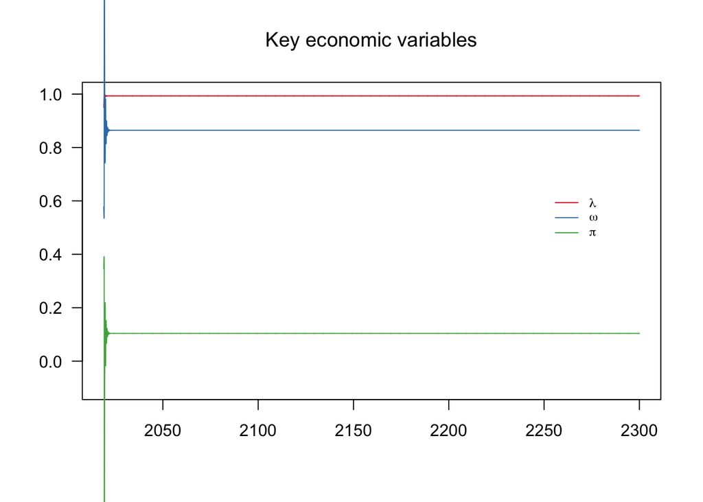

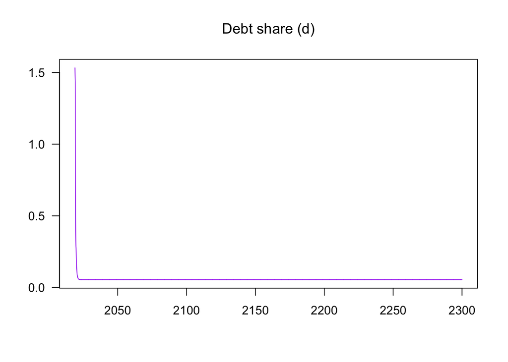

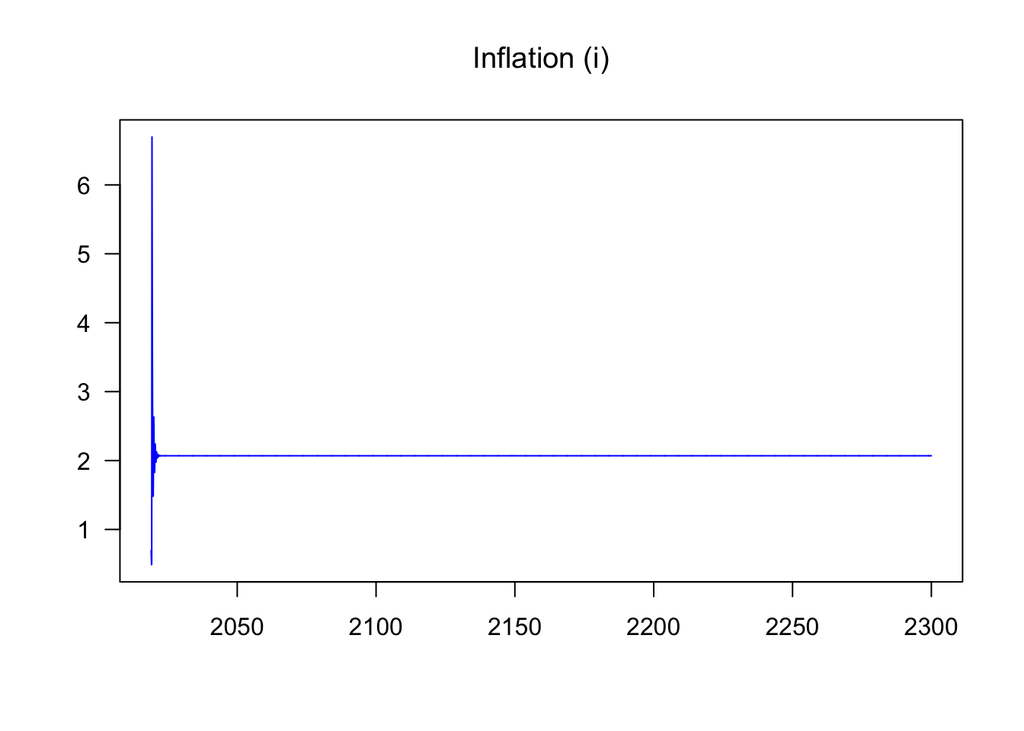

## Equilibria

Below is the work I have done so far in computing the equilibria of the model.

### Zero equilibrium

Clearly the zero Keen equilibrium exists for this set of equations. It is defined as $(\omega_0^*, \lambda_0^*, d_0^*) = (0,0,d_0^*)$ where $d_0^*$ solves
$$\begin{equation}
d_0^* = \frac{\kappa(1-r d_0^* - \delta \nu) +(1-r d_0^* - \delta \nu) \Delta(1-r d_0^* - \delta \nu) -1 }{\frac{\kappa(1-r d_0^* - \delta \nu)}{\nu} - r - \eta}
\end{equation}$$

### Standard Keen Equilibrium

Otherwise, starting with the differential equation for $\lambda$, we have:
$$0 = \frac{\kappa(\pi)}{\nu} - \delta - \alpha - \beta$$
i.e. that
$$\begin{equation}
\pi_1^* = \kappa^{-1}(\nu(\alpha + \beta + \delta))
\end{equation}$$

assuming as in Grasselli and Costa Lima (2012) that $\kappa^{-1}(\nu(\alpha + \beta + \delta))$ is defined.

From the differential equation for $\omega$, we have:
$$0 = \Phi(\lambda) - \alpha - \eta \, (\mu \omega - 1)$$
i.e.,
$$\begin{equation}
\lambda_1^* = \Phi^{-1}(\alpha + \eta \, (\mu \omega_1^* - 1))
\end{equation}$$
assuming that $\Phi^{-1}(\alpha + \eta \, (\mu \omega - 1))$ is defined.

By the definition of $\pi$, we have
$$\omega_1^* = 1 - \pi_1^* -r d_1^* - \delta \nu$$

and finally from the differential equation for debt we have
$$d_1^* = \frac{\kappa(\pi_1^*) + \pi_1^* [\Delta(\pi_1^*) -1] - \delta \nu}{i(\omega_1^*) + g(\pi_1^*)}$$

so the equilibrium point is
$$\begin{align}
\lambda_1^* &= \Phi^{-1}(\alpha + \eta \, (\mu \omega_1^* - 1)) \\
\omega_1^* &= 1 - \pi_1^* -r d_1^* - \delta \nu \\
d_1^* &= \frac{\kappa(\pi_1^*) + \pi_1^* [\Delta(\pi_1^*) -1] - \delta \nu}{i(\omega_1^*) + g(\pi_1^*)}
\end{align}$$

This corresponds to the equilibrium given in Grasselli and Nguyen Huu (2015) with the changes due to dividends and depreciation.

Since we have
$$d_1^* = \frac{1 - \omega_1^* - \pi_1^* - \delta \nu}{r}$$
and also
$$\begin{equation*}
d_1^* = \frac{\kappa(\pi_1^*) +\pi_1^*(\Delta(\pi_1^*) -1) - \delta \nu }{\frac{\kappa(\pi_1^*)}{\nu} - \delta + \eta \, (\mu \omega_1^* - 1)}
\end{equation*}$$
we solve for the equilibrium by equating the two.
$$\begin{equation*}
\frac{1 - \omega_1^* - \pi_1^* - \delta \nu}{r}
= \frac{\nu(\alpha + \beta + \delta) +\pi_1^*(\Delta(\pi_1^*) -1) - \delta \nu }{\alpha + \beta - \eta +\eta\mu \omega_1^*}
\end{equation*}$$
which gives us a quadratic expression in $\omega_1^*$.
$$(1 - \omega_1^* - \pi_1^* - \delta \nu)(\alpha + \beta - \eta +\eta\mu \omega_1^*)
= r(\nu(\alpha + \beta + \delta)+\pi_1^*(\Delta(\pi_1^*) -1) - \delta \nu)$$

$$(1 - \pi_1^* - \delta \nu)(\alpha + \beta - \eta) + (1 - \pi_1^* - \delta \nu)\eta \mu \omega_1^* - (\alpha + \beta - \eta)\omega_1^* - \eta \mu (\omega_1^*)^2 = r(\nu(\alpha + \beta + \delta) +\pi_1^*(\Delta(\pi_1^*) -1) - \delta \nu)$$

$$0 = \eta \mu (\omega_1^*)^2 + [(\alpha + \beta - \eta) - \eta \mu (1 - \pi_1^* - \delta \nu) ]\omega_1^* - (1 - \pi_1^* - \delta \nu)(\alpha + \beta - \eta) + r(\nu(\alpha + \beta + \delta) +\pi_1^*(\Delta(\pi_1^*) -1) - \delta \nu)$$

Using the quadratic formula, let:

$a = \eta \mu$,

$b = \alpha + \beta - \eta - \eta \mu (1 - \pi_1^* - \delta \nu)$

$c = - (1 - \pi_1^* - \delta \nu)(\alpha + \beta - \eta) + r(\nu(\alpha + \beta + \delta) +\pi_1^*(\Delta(\pi_1^*) -1) - \delta \nu)$

Then
$$\omega_1^* = \frac{-b \pm \sqrt{b^2 - 4ac}}{2a}$$

Since $d$ and $\lambda$ both depend on $\omega$ this could give us two positive equilibria, $(\omega_{1,1}^*, \lambda_{1,1}^*, d_{1,1}^*)$ and $(\omega_{1_2}^*, \lambda_{1,2}^*, d_{1,2}^*)$.

At this equilibrium, the auxiliary variables also converge. Clearly $\pi$ converges to $\pi_1^*$. The economy converges to the fixed growth rate $g(\pi_1^*) = \frac{\kappa(\pi_1^*)}{\nu} - \delta$, which should be positive. The inflation rate converges to $i(\omega_1^*) = \eta(\mu \omega_1^* - 1)$ which is positive if $\omega_1^* \geq \frac{1}{\mu}$

### Additional equilibria

As shown in Grasselli and Nguyen Huu (2015), there are two more equilibrium points found as follows:

If we have $\lambda = 0$, then from the differential equation for $\omega$ we get that
$$\omega_2^* = \frac{\Phi(0) - \alpha + \eta}{\eta \mu}$$
and $d_2^*$ solves the equation given by the differential equation for $d$:
$$0 = \kappa(1 - \omega_2^* - rd_2^* - \delta \nu) + (1 - \omega_2^* - rd_2^* - \delta \nu) [\Delta(1 - \omega_2^* - rd_2^* - \delta \nu) -1] - \delta \nu - d_2^* \left[ i(\omega_2^*) + g(1 - \omega_2^* - rd_2^* - \delta \nu) \right]$$

This gives the two possible equilibria $(0,\omega_2^*,d_2^*)$ and $(0,\omega_2^*,0)$.

## Computing the equilibrium

### Inverse functions

The Phillips curve is given by
$$\Phi(\lambda) = \frac{\phi_0}{(1 - \lambda)^2} - \phi_1$$
so its inverse is
$$\Phi^{-1}(x) = 1 - \sqrt{\frac{\phi_0}{x + \phi_1}}$$
defined when $x > -\phi_1$, so when $x >$ -0.0204 with our parameters.

```r
f_phill_inverse <- function(x, pars, active){
  switch(active$Phillips,
         'linear' = (x - pars[['Phill_lin_const']]) / pars[['Phill_slope']],
         'asymptotic' = 1 - sqrt(pars[['Phill_denom']] / (x - pars[['Phill_asymp_const']]))
  )
}
```

The investment function is
$$\kappa(\pi) = \kappa_0 + \kappa_1 \arctan(\kappa_2 \pi + \kappa_3)$$
so its inverse is
$$\kappa^{-1}(x) = \frac{\tan(\frac{x - \kappa_0}{\kappa_1}) - \kappa_3}{\kappa_2}$$

defined when $\frac{x - \kappa_0}{\kappa_1} \neq \frac{\pi}{2} + n \pi$ for some $n \in \mathbb{Z}$ (note that here $\pi$ is the mathematical constant).

```r
f_kappa_inverse <- function(x, pars, active) {
  switch(active$Scenario,
         'A' = (tan((x - pars[['kappa_0']])/pars[['kappa_1']]) -
                                    pars[['kappa_3']]) / pars[['kappa_2']],
         'B' = (tan((x - pars[['kappa_0']])/pars[['kappa_1']]) -
                                    pars[['kappa_3']]) / pars[['kappa_2']],
         'C' = (tan((x - pars[['kappa_0']])/pars[['kappa_1']]) -
                                    pars[['kappa_3_high']]) / pars[['kappa_2_high']],
         'D' = (tan((x - pars[['kappa_0']])/pars[['kappa_1']]) -
                                    pars[['kappa_3']]) / pars[['kappa_2']])
}
```

The following code computes the two equilibria described above. It is still a work in progress. Right now, $\alpha + \eta \, (\mu \omega - 1)$ is not in the image of the Phillips curve, violating the assumption that $\Phi^{-1}(\alpha + \eta \, (\mu \omega - 1))$ is defined.

I will look at changing the parameters in $i(\omega)$ to see if that can resolve this issue.

```r
parms <- Pars  # assign parameters

active <- list(
  Phillips     =   'asymptotic', # linear / asymptotic
  Invest       =   'arctan',     # linear / arctan
  Scenario     =   'A'           # A / B / C / D
)

# EQUILIBRIUM COMPUTATION
eq.compute <- function() {
  with(as.list(parms), {
    # Equilibrium profit share
    pi_eq <- f_kappa_inverse(x = nu * (alpha + beta + delta),
                             pars=parms, active=active)

    # Equilibrium omega
    a <- eta * mu
    b <- alpha + beta - eta - eta * mu * (1 - pi_eq - delta * nu)
    c <- r * (nu * (alpha + beta + delta) + pi_eq *
                      (f_div(pi = pi_eq, pars = parms, active = active) - 1) - delta * nu) -
      (1 - pi_eq - delta * nu) * (alpha + beta - eta)

    omega_eq_1 <- (-b + sqrt(b^2 - 4 * a * c)) / (2 * a)
    omega_eq_2 <- (-b - sqrt(b^2 - 4 * a * c)) / (2 * a)

    # Equilibrium debt
    debt_eq_1 <- (1 - omega_eq_1 - pi_eq - delta * nu) / r
    debt_eq_2 <- (1 - omega_eq_2 - pi_eq - delta * nu) / r

    cat("omega_1", omega_eq_1, "omega_2", omega_eq_2, "debt_1", debt_eq_1,
        "debt_2", debt_eq_2)

    # Equilibrium lambda
    x_1 <- alpha + eta * (mu * omega_eq_1 - 1)
    lambda_eq_1 <- f_phill_inverse(x = x_1, pars = parms, active = active)
    x_2 <- alpha + eta * (mu * omega_eq_2 - 1)
    lambda_eq_2 <- f_phill_inverse(x = x_2, pars = parms, active = active)

    # Return equilibria
    return(list(c(
      pi_eq       =  pi_eq,
      omega_eq_1  =  omega_eq_1,
      omega_eq_2  =  omega_eq_2,
      lambda_eq_1 =  lambda_eq_1,
      lambda_eq_2 =  lambda_eq_2,
      debt_eq_1   =  debt_eq_1,
      debt_eq_2   =  debt_eq_2)))
  })
}

equilibria <- eq.compute()
```

```
## omega_1 0.849615 omega_2 0.840442 debt_1 0.5494572 debt_2 0.8552236
```